# Risk Factor Analysis

## Outcome Variable

**Outcome Variable:** ever_stunted

## Predictor Variables

**Intervention Variable:** impsan

**Adjustment Set:**

- arm
- W_mage
- meducyrs
- feducyrs
- hhwealth_quart
- hfoodsec
- W_mhtcm
- W_mwtkg
- W_mbmi
- W_nrooms
- W_nchldlt5
- W_parity
- impfloor
- safeh20
- delta_W_mage
- delta_meducyrs
- delta_feducyrs
- delta_hhwealth_quart
- delta_hfoodsec
- delta_W_mhtcm
- delta_W_mwtkg
- delta_W_mbmi
- delta_W_nrooms
- delta_W_nchldlt5
- delta_W_parity
- delta_impfloor
- delta_safeh20

## Stratifying Variables

The analysis was stratified on these variable(s):

- agecat
- studyid
- country

## Data Summary

| agecat | studyid | country | impsan | ever_stunted | n_cell | n |
| --- | --- | --- | --- | --- | --- | --- |
| 0-24 months (no birth st.) | COHORTS | GUATEMALA | 1 | 0 | 16 | 635 |
| 0-24 months (no birth st.) | COHORTS | GUATEMALA | 1 | 1 | 49 | 635 |
| 0-24 months (no birth st.) | COHORTS | GUATEMALA | 0 | 0 | 104 | 635 |
| 0-24 months (no birth st.) | COHORTS | GUATEMALA | 0 | 1 | 466 | 635 |
| 0-24 months (no birth st.) | COHORTS | INDIA | 1 | 0 | 1423 | 4715 |
| 0-24 months (no birth st.) | COHORTS | INDIA | 1 | 1 | 389 | 4715 |
| 0-24 months (no birth st.) | COHORTS | INDIA | 0 | 0 | 1871 | 4715 |
| 0-24 months (no birth st.) | COHORTS | INDIA | 0 | 1 | 1032 | 4715 |
| 0-24 months (no birth st.) | COHORTS | PHILIPPINES | 1 | 0 | 102 | 1115 |
| 0-24 months (no birth st.) | COHORTS | PHILIPPINES | 1 | 1 | 75 | 1115 |
| 0-24 months (no birth st.) | COHORTS | PHILIPPINES | 0 | 0 | 207 | 1115 |
| 0-24 months (no birth st.) | COHORTS | PHILIPPINES | 0 | 1 | 731 | 1115 |
| 0-24 months (no birth st.) | CONTENT | PERU | 1 | 0 | 154 | 195 |
| 0-24 months (no birth st.) | CONTENT | PERU | 1 | 1 | 29 | 195 |
| 0-24 months (no birth st.) | CONTENT | PERU | 0 | 0 | 8 | 195 |
| 0-24 months (no birth st.) | CONTENT | PERU | 0 | 1 | 4 | 195 |
| 0-24 months (no birth st.) | JiVitA-3 | BANGLADESH | 1 | 0 | 10052 | 18353 |
| 0-24 months (no birth st.) | JiVitA-3 | BANGLADESH | 1 | 1 | 3074 | 18353 |
| 0-24 months (no birth st.) | JiVitA-3 | BANGLADESH | 0 | 0 | 3669 | 18353 |
| 0-24 months (no birth st.) | JiVitA-3 | BANGLADESH | 0 | 1 | 1558 | 18353 |
| 0-24 months (no birth st.) | JiVitA-4 | BANGLADESH | 1 | 0 | 1830 | 3875 |
| 0-24 months (no birth st.) | JiVitA-4 | BANGLADESH | 1 | 1 | 1217 | 3875 |
| 0-24 months (no birth st.) | JiVitA-4 | BANGLADESH | 0 | 0 | 439 | 3875 |
| 0-24 months (no birth st.) | JiVitA-4 | BANGLADESH | 0 | 1 | 389 | 3875 |
| 0-24 months (no birth st.) | LCNI-5 | MALAWI | 1 | 0 | 2 | 518 |
| 0-24 months (no birth st.) | LCNI-5 | MALAWI | 1 | 1 | 0 | 518 |
| 0-24 months (no birth st.) | LCNI-5 | MALAWI | 0 | 0 | 293 | 518 |
| 0-24 months (no birth st.) | LCNI-5 | MALAWI | 0 | 1 | 223 | 518 |
| 0-24 months (no birth st.) | MAL-ED | BANGLADESH | 1 | 0 | 82 | 203 |
| 0-24 months (no birth st.) | MAL-ED | BANGLADESH | 1 | 1 | 88 | 203 |

[output cut: 174 more lines]

The following strata were considered:

- agecat: 0-24 months (no birth st.), studyid: COHORTS, country: GUATEMALA
- agecat: 0-24 months (no birth st.), studyid: COHORTS, country: INDIA
- agecat: 0-24 months (no birth st.), studyid: COHORTS, country: PHILIPPINES
- agecat: 0-24 months (no birth st.), studyid: CONTENT, country: PERU
- agecat: 0-24 months (no birth st.), studyid: JiVitA-3, country: BANGLADESH
- agecat: 0-24 months (no birth st.), studyid: JiVitA-4, country: BANGLADESH
- agecat: 0-24 months (no birth st.), studyid: LCNI-5, country: MALAWI
- agecat: 0-24 months (no birth st.), studyid: MAL-ED, country: BANGLADESH
- agecat: 0-24 months (no birth st.), studyid: MAL-ED, country: BRAZIL
- agecat: 0-24 months (no birth st.), studyid: MAL-ED, country: INDIA
- agecat: 0-24 months (no birth st.), studyid: MAL-ED, country: NEPAL
- agecat: 0-24 months (no birth st.), studyid: MAL-ED, country: PERU
- agecat: 0-24 months (no birth st.), studyid: MAL-ED, country: SOUTH AFRICA
- agecat: 0-24 months (no birth st.), studyid: MAL-ED, country: TANZANIA, UNITED REPUBLIC OF
- agecat: 0-24 months (no birth st.), studyid: NIH-Birth, country: BANGLADESH
- agecat: 0-24 months (no birth st.), studyid: NIH-Crypto, country: BANGLADESH
- agecat: 0-24 months (no birth st.), studyid: PROVIDE, country: BANGLADESH
- agecat: 0-6 months (no birth st.), studyid: COHORTS, country: GUATEMALA
- agecat: 0-6 months (no birth st.), studyid: COHORTS, country: INDIA
- agecat: 0-6 months (no birth st.), studyid: COHORTS, country: PHILIPPINES
- agecat: 0-6 months (no birth st.), studyid: CONTENT, country: PERU
- agecat: 0-6 months (no birth st.), studyid: JiVitA-3, country: BANGLADESH
- agecat: 0-6 months (no birth st.), studyid: JiVitA-4, country: BANGLADESH
- agecat: 0-6 months (no birth st.), studyid: LCNI-5, country: MALAWI
- agecat: 0-6 months (no birth st.), studyid: MAL-ED, country: BANGLADESH
- agecat: 0-6 months (no birth st.), studyid: MAL-ED, country: BRAZIL
- agecat: 0-6 months (no birth st.), studyid: MAL-ED, country: INDIA
- agecat: 0-6 months (no birth st.), studyid: MAL-ED, country: NEPAL
- agecat: 0-6 months (no birth st.), studyid: MAL-ED, country: PERU
- agecat: 0-6 months (no birth st.), studyid: MAL-ED, country: SOUTH AFRICA
- agecat: 0-6 months (no birth st.), studyid: MAL-ED, country: TANZANIA, UNITED REPUBLIC OF
- agecat: 0-6 months (no birth st.), studyid: NIH-Birth, country: BANGLADESH
- agecat: 0-6 months (no birth st.), studyid: NIH-Crypto, country: BANGLADESH
- agecat: 0-6 months (no birth st.), studyid: PROVIDE, country: BANGLADESH
- agecat: 6-24 months, studyid: COHORTS, country: GUATEMALA
- agecat: 6-24 months, studyid: COHORTS, country: INDIA
- agecat: 6-24 months, studyid: COHORTS, country: PHILIPPINES
- agecat: 6-24 months, studyid: CONTENT, country: PERU
- agecat: 6-24 months, studyid: JiVitA-3, country: BANGLADESH
- agecat: 6-24 months, studyid: JiVitA-4, country: BANGLADESH
- agecat: 6-24 months, studyid: LCNI-5, country: MALAWI
- agecat: 6-24 months, studyid: MAL-ED, country: BANGLADESH
- agecat: 6-24 months, studyid: MAL-ED, country: BRAZIL
- agecat: 6-24 months, studyid: MAL-ED, country: INDIA
- agecat: 6-24 months, studyid: MAL-ED, country: NEPAL
- agecat: 6-24 months, studyid: MAL-ED, country: PERU
- agecat: 6-24 months, studyid: MAL-ED, country: SOUTH AFRICA
- agecat: 6-24 months, studyid: MAL-ED, country: TANZANIA, UNITED REPUBLIC OF
- agecat: 6-24 months, studyid: NIH-Birth, country: BANGLADESH
- agecat: 6-24 months, studyid: NIH-Crypto, country: BANGLADESH
- agecat: 6-24 months, studyid: PROVIDE, country: BANGLADESH

### Dropped Strata

Some strata were dropped due to rare outcomes:

- agecat: 0-24 months (no birth st.), studyid: CONTENT, country: PERU
- agecat: 0-24 months (no birth st.), studyid: LCNI-5, country: MALAWI
- agecat: 0-24 months (no birth st.), studyid: MAL-ED, country: BRAZIL
- agecat: 0-24 months (no birth st.), studyid: MAL-ED, country: NEPAL
- agecat: 0-24 months (no birth st.), studyid: MAL-ED, country: SOUTH AFRICA
- agecat: 0-24 months (no birth st.), studyid: MAL-ED, country: TANZANIA, UNITED REPUBLIC OF
- agecat: 0-24 months (no birth st.), studyid: PROVIDE, country: BANGLADESH
- agecat: 0-6 months (no birth st.), studyid: CONTENT, country: PERU
- agecat: 0-6 months (no birth st.), studyid: LCNI-5, country: MALAWI
- agecat: 0-6 months (no birth st.), studyid: MAL-ED, country: BRAZIL
- agecat: 0-6 months (no birth st.), studyid: MAL-ED, country: NEPAL
- agecat: 0-6 months (no birth st.), studyid: MAL-ED, country: SOUTH AFRICA
- agecat: 0-6 months (no birth st.), studyid: MAL-ED, country: TANZANIA, UNITED REPUBLIC OF
- agecat: 0-6 months (no birth st.), studyid: PROVIDE, country: BANGLADESH
- agecat: 6-24 months, studyid: CONTENT, country: PERU
- agecat: 6-24 months, studyid: LCNI-5, country: MALAWI
- agecat: 6-24 months, studyid: MAL-ED, country: BRAZIL
- agecat: 6-24 months, studyid: MAL-ED, country: NEPAL
- agecat: 6-24 months, studyid: MAL-ED, country: SOUTH AFRICA
- agecat: 6-24 months, studyid: MAL-ED, country: TANZANIA, UNITED REPUBLIC OF
- agecat: 6-24 months, studyid: PROVIDE, country: BANGLADESH

## Methods Detail

We’re interested in the causal parameters $E[Y_a]$ for all values of $a \in \mathcal{A}$. These parameters represent the mean outcome if, possibly contrary to fact, we intervened to set all units to have $A=a$. Under the randomization and positivity assumptions, these are identified by the statistical parameters $\psi_a=E_W[E_{Y|A,W}(Y|A=a,W)]$. In addition, we’re interested in the mean of $Y$, $E[Y]$ under no intervention (the observed mean). We will estimate these parameters by using SuperLearner to fit the relevant likelihood factors – $E_{Y|A,W}(Y|A=a,W)$ and $p(A=a|W)$, and then updating our likelihood fit using a joint TMLE.

For unadjusted analyses ($W=\{\}$), initial likelihoods were estimated using Lrnr_glm to estimate the simple $E(Y|A)$ and Lrnr_mean to estimate $p(A)$. For adjusted analyses, a small library containing Lrnr_glmnet, Lrnr_xgboost, and Lrnr_mean was used.

Having estimated these parameters, we will then use the delta method to estimate relative risks and attributable risks relative to a prespecified baseline level of $A$.

# Results Detail

## Results Plots

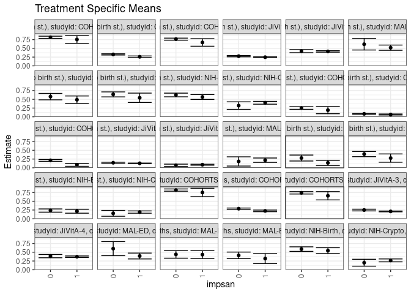

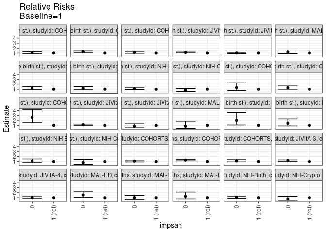

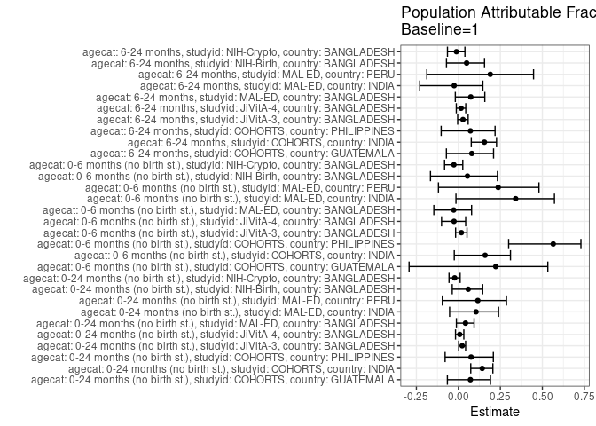

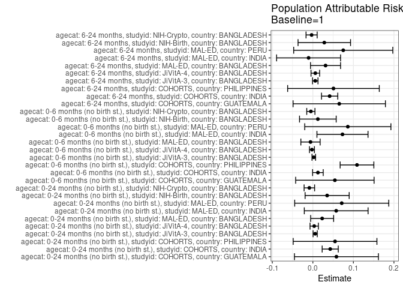

## Results Table

### Parameter: TSM

| agecat | studyid | country | intervention_level | baseline_level | estimate | ci_lower | ci_upper |
| --- | --- | --- | --- | --- | --- | --- | --- |
| 0-24 months (no birth st.) | COHORTS | GUATEMALA | 1 | NA | 0.7529024 | 0.6427975 | 0.8630073 |
| 0-24 months (no birth st.) | COHORTS | GUATEMALA | 0 | NA | 0.8149509 | 0.7830603 | 0.8468414 |
| 0-24 months (no birth st.) | COHORTS | INDIA | 1 | NA | 0.2585530 | 0.2353733 | 0.2817327 |
| 0-24 months (no birth st.) | COHORTS | INDIA | 0 | NA | 0.3262474 | 0.3091038 | 0.3433909 |
| 0-24 months (no birth st.) | COHORTS | PHILIPPINES | 1 | NA | 0.6681217 | 0.5603339 | 0.7759095 |
| 0-24 months (no birth st.) | COHORTS | PHILIPPINES | 0 | NA | 0.7620937 | 0.7326072 | 0.7915802 |
| 0-24 months (no birth st.) | JiVitA-3 | BANGLADESH | 1 | NA | 0.2466584 | 0.2372120 | 0.2561049 |
| 0-24 months (no birth st.) | JiVitA-3 | BANGLADESH | 0 | NA | 0.2754592 | 0.2572077 | 0.2937106 |
| 0-24 months (no birth st.) | JiVitA-4 | BANGLADESH | 1 | NA | 0.4111209 | 0.3901882 | 0.4320537 |
| 0-24 months (no birth st.) | JiVitA-4 | BANGLADESH | 0 | NA | 0.4196225 | 0.3754533 | 0.4637917 |
| 0-24 months (no birth st.) | MAL-ED | BANGLADESH | 1 | NA | 0.5189213 | 0.4442760 | 0.5935666 |
| 0-24 months (no birth st.) | MAL-ED | BANGLADESH | 0 | NA | 0.6168470 | 0.4525021 | 0.7811919 |
| 0-24 months (no birth st.) | MAL-ED | INDIA | 1 | NA | 0.4883596 | 0.3814994 | 0.5952198 |
| 0-24 months (no birth st.) | MAL-ED | INDIA | 0 | NA | 0.5773280 | 0.4856261 | 0.6690299 |
| 0-24 months (no birth st.) | MAL-ED | PERU | 1 | NA | 0.5434725 | 0.4099697 | 0.6769754 |
| 0-24 months (no birth st.) | MAL-ED | PERU | 0 | NA | 0.6407755 | 0.5695843 | 0.7119667 |
| 0-24 months (no birth st.) | NIH-Birth | BANGLADESH | 1 | NA | 0.5666644 | 0.4968617 | 0.6364671 |
| 0-24 months (no birth st.) | NIH-Birth | BANGLADESH | 0 | NA | 0.6242218 | 0.5721976 | 0.6762460 |
| 0-24 months (no birth st.) | NIH-Crypto | BANGLADESH | 1 | NA | 0.4005499 | 0.3603843 | 0.4407155 |
| 0-24 months (no birth st.) | NIH-Crypto | BANGLADESH | 0 | NA | 0.3202513 | 0.2123062 | 0.4281963 |
| 0-6 months (no birth st.) | COHORTS | GUATEMALA | 1 | NA | 0.1899058 | 0.0884982 | 0.2913134 |
| 0-6 months (no birth st.) | COHORTS | GUATEMALA | 0 | NA | 0.2509152 | 0.2131309 | 0.2886994 |
| 0-6 months (no birth st.) | COHORTS | INDIA | 1 | NA | 0.0658679 | 0.0512431 | 0.0804928 |
| 0-6 months (no birth st.) | COHORTS | INDIA | 0 | NA | 0.0844635 | 0.0744330 | 0.0944940 |
| 0-6 months (no birth st.) | COHORTS | PHILIPPINES | 1 | NA | 0.0839342 | 0.0423548 | 0.1255136 |
| 0-6 months (no birth st.) | COHORTS | PHILIPPINES | 0 | NA | 0.2128360 | 0.1866338 | 0.2390382 |
| 0-6 months (no birth st.) | JiVitA-3 | BANGLADESH | 1 | NA | 0.1280253 | 0.1208879 | 0.1351627 |
| 0-6 months (no birth st.) | JiVitA-3 | BANGLADESH | 0 | NA | 0.1441563 | 0.1301471 | 0.1581656 |
| 0-6 months (no birth st.) | JiVitA-4 | BANGLADESH | 1 | NA | 0.0876648 | 0.0746004 | 0.1007291 |
| 0-6 months (no birth st.) | JiVitA-4 | BANGLADESH | 0 | NA | 0.0722302 | 0.0405257 | 0.1039347 |
| 0-6 months (no birth st.) | MAL-ED | BANGLADESH | 1 | NA | 0.2176471 | 0.1554638 | 0.2798304 |
| 0-6 months (no birth st.) | MAL-ED | BANGLADESH | 0 | NA | 0.1818182 | 0.0498993 | 0.3137371 |
| 0-6 months (no birth st.) | MAL-ED | INDIA | 1 | NA | 0.1412116 | 0.0677457 | 0.2146775 |
| 0-6 months (no birth st.) | MAL-ED | INDIA | 0 | NA | 0.2789963 | 0.1937365 | 0.3642562 |
| 0-6 months (no birth st.) | MAL-ED | PERU | 1 | NA | 0.2773895 | 0.1583610 | 0.3964180 |
| 0-6 months (no birth st.) | MAL-ED | PERU | 0 | NA | 0.3917649 | 0.3183703 | 0.4651595 |
| 0-6 months (no birth st.) | NIH-Birth | BANGLADESH | 1 | NA | 0.2159696 | 0.1594458 | 0.2724935 |
| 0-6 months (no birth st.) | NIH-Birth | BANGLADESH | 0 | NA | 0.2354123 | 0.1892495 | 0.2815751 |
| 0-6 months (no birth st.) | NIH-Crypto | BANGLADESH | 1 | NA | 0.1915749 | 0.1592510 | 0.2238988 |
| 0-6 months (no birth st.) | NIH-Crypto | BANGLADESH | 0 | NA | 0.1545475 | 0.0712294 | 0.2378655 |
| 6-24 months | COHORTS | GUATEMALA | 1 | NA | 0.7512071 | 0.6307005 | 0.8717138 |
| 6-24 months | COHORTS | GUATEMALA | 0 | NA | 0.8202701 | 0.7885011 | 0.8520391 |
| 6-24 months | COHORTS | INDIA | 1 | NA | 0.2252817 | 0.2018641 | 0.2486992 |
| 6-24 months | COHORTS | INDIA | 0 | NA | 0.2884224 | 0.2705696 | 0.3062753 |
| 6-24 months | COHORTS | PHILIPPINES | 1 | NA | 0.6577849 | 0.5393023 | 0.7762675 |
| 6-24 months | COHORTS | PHILIPPINES | 0 | NA | 0.7413280 | 0.7072147 | 0.7754413 |
| 6-24 months | JiVitA-3 | BANGLADESH | 1 | NA | 0.2102751 | 0.1985535 | 0.2219967 |
| 6-24 months | JiVitA-3 | BANGLADESH | 0 | NA | 0.2492029 | 0.2247996 | 0.2736062 |
| 6-24 months | JiVitA-4 | BANGLADESH | 1 | NA | 0.3723256 | 0.3511280 | 0.3935232 |
| 6-24 months | JiVitA-4 | BANGLADESH | 0 | NA | 0.3895397 | 0.3423849 | 0.4366945 |
| 6-24 months | MAL-ED | BANGLADESH | 1 | NA | 0.3927490 | 0.3087255 | 0.4767725 |
| 6-24 months | MAL-ED | BANGLADESH | 0 | NA | 0.6035661 | 0.4026055 | 0.8045267 |
| 6-24 months | MAL-ED | INDIA | 1 | NA | 0.4326118 | 0.3208394 | 0.5443841 |
| 6-24 months | MAL-ED | INDIA | 0 | NA | 0.4386173 | 0.3301777 | 0.5470570 |
| 6-24 months | MAL-ED | PERU | 1 | NA | 0.3195880 | 0.1776955 | 0.4614804 |
| 6-24 months | MAL-ED | PERU | 0 | NA | 0.4113118 | 0.3172627 | 0.5053609 |
| 6-24 months | NIH-Birth | BANGLADESH | 1 | NA | 0.5456862 | 0.4611797 | 0.6301927 |
| 6-24 months | NIH-Birth | BANGLADESH | 0 | NA | 0.5899254 | 0.5241267 | 0.6557240 |
| 6-24 months | NIH-Crypto | BANGLADESH | 1 | NA | 0.2670828 | 0.2257329 | 0.3084326 |
| 6-24 months | NIH-Crypto | BANGLADESH | 0 | NA | 0.2007635 | 0.1023255 | 0.2992014 |

### Parameter: E(Y)

| agecat | studyid | country | intervention_level | baseline_level | estimate | ci_lower | ci_upper |
| --- | --- | --- | --- | --- | --- | --- | --- |
| 0-24 months (no birth st.) | COHORTS | GUATEMALA | NA | NA | 0.8110236 | 0.7805500 | 0.8414972 |
| 0-24 months (no birth st.) | COHORTS | INDIA | NA | NA | 0.3013786 | 0.2882798 | 0.3144773 |
| 0-24 months (no birth st.) | COHORTS | PHILIPPINES | NA | NA | 0.7228700 | 0.6965868 | 0.7491531 |
| 0-24 months (no birth st.) | JiVitA-3 | BANGLADESH | NA | NA | 0.2523838 | 0.2446469 | 0.2601207 |
| 0-24 months (no birth st.) | JiVitA-4 | BANGLADESH | NA | NA | 0.4144516 | 0.3962595 | 0.4326437 |
| 0-24 months (no birth st.) | MAL-ED | BANGLADESH | NA | NA | 0.5418719 | 0.4731628 | 0.6105810 |
| 0-24 months (no birth st.) | MAL-ED | INDIA | NA | NA | 0.5459184 | 0.4760370 | 0.6157998 |
| 0-24 months (no birth st.) | MAL-ED | PERU | NA | NA | 0.6147186 | 0.5518243 | 0.6776129 |
| 0-24 months (no birth st.) | NIH-Birth | BANGLADESH | NA | NA | 0.6018868 | 0.5601729 | 0.6436007 |
| 0-24 months (no birth st.) | NIH-Crypto | BANGLADESH | NA | NA | 0.3919129 | 0.3541506 | 0.4296752 |
| 0-6 months (no birth st.) | COHORTS | GUATEMALA | NA | NA | 0.2442478 | 0.2087898 | 0.2797057 |
| 0-6 months (no birth st.) | COHORTS | INDIA | NA | NA | 0.0783541 | 0.0705612 | 0.0861470 |
| 0-6 months (no birth st.) | COHORTS | PHILIPPINES | NA | NA | 0.1928251 | 0.1696580 | 0.2159922 |
| 0-6 months (no birth st.) | JiVitA-3 | BANGLADESH | NA | NA | 0.1303730 | 0.1247937 | 0.1359524 |
| 0-6 months (no birth st.) | JiVitA-4 | BANGLADESH | NA | NA | 0.0854560 | 0.0740923 | 0.0968198 |
| 0-6 months (no birth st.) | MAL-ED | BANGLADESH | NA | NA | 0.2118227 | 0.1554757 | 0.2681696 |
| 0-6 months (no birth st.) | MAL-ED | INDIA | NA | NA | 0.2142857 | 0.1566940 | 0.2718774 |
| 0-6 months (no birth st.) | MAL-ED | PERU | NA | NA | 0.3636364 | 0.3014678 | 0.4258049 |
| 0-6 months (no birth st.) | NIH-Birth | BANGLADESH | NA | NA | 0.2283019 | 0.1925336 | 0.2640702 |
| 0-6 months (no birth st.) | NIH-Crypto | BANGLADESH | NA | NA | 0.1866252 | 0.1564874 | 0.2167630 |
| 6-24 months | COHORTS | GUATEMALA | NA | NA | 0.8162939 | 0.7859345 | 0.8466533 |
| 6-24 months | COHORTS | INDIA | NA | NA | 0.2666991 | 0.2531888 | 0.2802093 |
| 6-24 months | COHORTS | PHILIPPINES | NA | NA | 0.7086331 | 0.6777759 | 0.7394903 |
| 6-24 months | JiVitA-3 | BANGLADESH | NA | NA | 0.2162136 | 0.2068317 | 0.2255956 |
| 6-24 months | JiVitA-4 | BANGLADESH | NA | NA | 0.3784303 | 0.3598372 | 0.3970234 |
| 6-24 months | MAL-ED | BANGLADESH | NA | NA | 0.4240506 | 0.3467471 | 0.5013542 |
| 6-24 months | MAL-ED | INDIA | NA | NA | 0.4220779 | 0.3438191 | 0.5003367 |
| 6-24 months | MAL-ED | PERU | NA | NA | 0.3945578 | 0.3152779 | 0.4738378 |
| 6-24 months | NIH-Birth | BANGLADESH | NA | NA | 0.5739130 | 0.5216565 | 0.6261696 |
| 6-24 months | NIH-Crypto | BANGLADESH | NA | NA | 0.2640000 | 0.2253243 | 0.3026757 |

### Parameter: RR

| agecat | studyid | country | intervention_level | baseline_level | estimate | ci_lower | ci_upper |
| --- | --- | --- | --- | --- | --- | --- | --- |
| 0-24 months (no birth st.) | COHORTS | GUATEMALA | 1 | 1 | 1.0000000 | 1.0000000 | 1.000000 |
| 0-24 months (no birth st.) | COHORTS | GUATEMALA | 0 | 1 | 1.0824124 | 0.9309749 | 1.258484 |
| 0-24 months (no birth st.) | COHORTS | INDIA | 1 | 1 | 1.0000000 | 1.0000000 | 1.000000 |
| 0-24 months (no birth st.) | COHORTS | INDIA | 0 | 1 | 1.2618200 | 1.1387113 | 1.398238 |
| 0-24 months (no birth st.) | COHORTS | PHILIPPINES | 1 | 1 | 1.0000000 | 1.0000000 | 1.000000 |
| 0-24 months (no birth st.) | COHORTS | PHILIPPINES | 0 | 1 | 1.1406510 | 0.9670409 | 1.345429 |
| 0-24 months (no birth st.) | JiVitA-3 | BANGLADESH | 1 | 1 | 1.0000000 | 1.0000000 | 1.000000 |
| 0-24 months (no birth st.) | JiVitA-3 | BANGLADESH | 0 | 1 | 1.1167637 | 1.0391283 | 1.200199 |
| 0-24 months (no birth st.) | JiVitA-4 | BANGLADESH | 1 | 1 | 1.0000000 | 1.0000000 | 1.000000 |
| 0-24 months (no birth st.) | JiVitA-4 | BANGLADESH | 0 | 1 | 1.0206789 | 0.9090330 | 1.146037 |
| 0-24 months (no birth st.) | MAL-ED | BANGLADESH | 1 | 1 | 1.0000000 | 1.0000000 | 1.000000 |
| 0-24 months (no birth st.) | MAL-ED | BANGLADESH | 0 | 1 | 1.1887101 | 0.8831818 | 1.599933 |
| 0-24 months (no birth st.) | MAL-ED | INDIA | 1 | 1 | 1.0000000 | 1.0000000 | 1.000000 |
| 0-24 months (no birth st.) | MAL-ED | INDIA | 0 | 1 | 1.1821781 | 0.9033990 | 1.546985 |
| 0-24 months (no birth st.) | MAL-ED | PERU | 1 | 1 | 1.0000000 | 1.0000000 | 1.000000 |
| 0-24 months (no birth st.) | MAL-ED | PERU | 0 | 1 | 1.1790393 | 0.8996232 | 1.545240 |
| 0-24 months (no birth st.) | NIH-Birth | BANGLADESH | 1 | 1 | 1.0000000 | 1.0000000 | 1.000000 |
| 0-24 months (no birth st.) | NIH-Birth | BANGLADESH | 0 | 1 | 1.1015723 | 0.9508965 | 1.276124 |
| 0-24 months (no birth st.) | NIH-Crypto | BANGLADESH | 1 | 1 | 1.0000000 | 1.0000000 | 1.000000 |
| 0-24 months (no birth st.) | NIH-Crypto | BANGLADESH | 0 | 1 | 0.7995291 | 0.5636263 | 1.134168 |
| 0-6 months (no birth st.) | COHORTS | GUATEMALA | 1 | 1 | 1.0000000 | 1.0000000 | 1.000000 |
| 0-6 months (no birth st.) | COHORTS | GUATEMALA | 0 | 1 | 1.3212611 | 0.7594277 | 2.298746 |
| 0-6 months (no birth st.) | COHORTS | INDIA | 1 | 1 | 1.0000000 | 1.0000000 | 1.000000 |
| 0-6 months (no birth st.) | COHORTS | INDIA | 0 | 1 | 1.2823160 | 0.9973763 | 1.648660 |
| 0-6 months (no birth st.) | COHORTS | PHILIPPINES | 1 | 1 | 1.0000000 | 1.0000000 | 1.000000 |
| 0-6 months (no birth st.) | COHORTS | PHILIPPINES | 0 | 1 | 2.5357477 | 1.5218601 | 4.225104 |
| 0-6 months (no birth st.) | JiVitA-3 | BANGLADESH | 1 | 1 | 1.0000000 | 1.0000000 | 1.000000 |
| 0-6 months (no birth st.) | JiVitA-3 | BANGLADESH | 0 | 1 | 1.1259987 | 1.0103935 | 1.254831 |
| 0-6 months (no birth st.) | JiVitA-4 | BANGLADESH | 1 | 1 | 1.0000000 | 1.0000000 | 1.000000 |
| 0-6 months (no birth st.) | JiVitA-4 | BANGLADESH | 0 | 1 | 0.8239365 | 0.5214810 | 1.301814 |
| 0-6 months (no birth st.) | MAL-ED | BANGLADESH | 1 | 1 | 1.0000000 | 1.0000000 | 1.000000 |
| 0-6 months (no birth st.) | MAL-ED | BANGLADESH | 0 | 1 | 0.8353808 | 0.3830278 | 1.821959 |
| 0-6 months (no birth st.) | MAL-ED | INDIA | 1 | 1 | 1.0000000 | 1.0000000 | 1.000000 |
| 0-6 months (no birth st.) | MAL-ED | INDIA | 0 | 1 | 1.9757324 | 1.0797969 | 3.615049 |
| 0-6 months (no birth st.) | MAL-ED | PERU | 1 | 1 | 1.0000000 | 1.0000000 | 1.000000 |
| 0-6 months (no birth st.) | MAL-ED | PERU | 0 | 1 | 1.4123277 | 0.8846913 | 2.254650 |
| 0-6 months (no birth st.) | NIH-Birth | BANGLADESH | 1 | 1 | 1.0000000 | 1.0000000 | 1.000000 |
| 0-6 months (no birth st.) | NIH-Birth | BANGLADESH | 0 | 1 | 1.0900250 | 0.7881270 | 1.507567 |
| 0-6 months (no birth st.) | NIH-Crypto | BANGLADESH | 1 | 1 | 1.0000000 | 1.0000000 | 1.000000 |
| 0-6 months (no birth st.) | NIH-Crypto | BANGLADESH | 0 | 1 | 0.8067208 | 0.4588123 | 1.418441 |
| 6-24 months | COHORTS | GUATEMALA | 1 | 1 | 1.0000000 | 1.0000000 | 1.000000 |
| 6-24 months | COHORTS | GUATEMALA | 0 | 1 | 1.0919360 | 0.9263185 | 1.287165 |
| 6-24 months | COHORTS | INDIA | 1 | 1 | 1.0000000 | 1.0000000 | 1.000000 |
| 6-24 months | COHORTS | INDIA | 0 | 1 | 1.2802747 | 1.1358175 | 1.443104 |
| 6-24 months | COHORTS | PHILIPPINES | 1 | 1 | 1.0000000 | 1.0000000 | 1.000000 |
| 6-24 months | COHORTS | PHILIPPINES | 0 | 1 | 1.1270067 | 0.9366452 | 1.356057 |
| 6-24 months | JiVitA-3 | BANGLADESH | 1 | 1 | 1.0000000 | 1.0000000 | 1.000000 |
| 6-24 months | JiVitA-3 | BANGLADESH | 0 | 1 | 1.1851279 | 1.0633865 | 1.320807 |
| 6-24 months | JiVitA-4 | BANGLADESH | 1 | 1 | 1.0000000 | 1.0000000 | 1.000000 |
| 6-24 months | JiVitA-4 | BANGLADESH | 0 | 1 | 1.0462340 | 0.9153986 | 1.195769 |
| 6-24 months | MAL-ED | BANGLADESH | 1 | 1 | 1.0000000 | 1.0000000 | 1.000000 |
| 6-24 months | MAL-ED | BANGLADESH | 0 | 1 | 1.5367731 | 1.0354673 | 2.280778 |
| 6-24 months | MAL-ED | INDIA | 1 | 1 | 1.0000000 | 1.0000000 | 1.000000 |
| 6-24 months | MAL-ED | INDIA | 0 | 1 | 1.0138821 | 0.7098363 | 1.448161 |
| 6-24 months | MAL-ED | PERU | 1 | 1 | 1.0000000 | 1.0000000 | 1.000000 |
| 6-24 months | MAL-ED | PERU | 0 | 1 | 1.2870066 | 0.7791610 | 2.125858 |
| 6-24 months | NIH-Birth | BANGLADESH | 1 | 1 | 1.0000000 | 1.0000000 | 1.000000 |
| 6-24 months | NIH-Birth | BANGLADESH | 0 | 1 | 1.0810707 | 0.8962188 | 1.304050 |
| 6-24 months | NIH-Crypto | BANGLADESH | 1 | 1 | 1.0000000 | 1.0000000 | 1.000000 |
| 6-24 months | NIH-Crypto | BANGLADESH | 0 | 1 | 0.7516901 | 0.4490303 | 1.258352 |

### Parameter: PAR

| agecat | studyid | country | intervention_level | baseline_level | estimate | ci_lower | ci_upper |
| --- | --- | --- | --- | --- | --- | --- | --- |
| 0-24 months (no birth st.) | COHORTS | GUATEMALA | 1 | NA | 0.0581212 | -0.0454185 | 0.1616609 |
| 0-24 months (no birth st.) | COHORTS | INDIA | 1 | NA | 0.0428256 | 0.0229689 | 0.0626823 |
| 0-24 months (no birth st.) | COHORTS | PHILIPPINES | 1 | NA | 0.0547482 | -0.0485350 | 0.1580315 |
| 0-24 months (no birth st.) | JiVitA-3 | BANGLADESH | 1 | NA | 0.0057254 | 0.0005411 | 0.0109097 |
| 0-24 months (no birth st.) | JiVitA-4 | BANGLADESH | 1 | NA | 0.0033307 | -0.0069364 | 0.0135977 |
| 0-24 months (no birth st.) | MAL-ED | BANGLADESH | 1 | NA | 0.0229506 | -0.0053734 | 0.0512746 |
| 0-24 months (no birth st.) | MAL-ED | INDIA | 1 | NA | 0.0575588 | -0.0210904 | 0.1362080 |
| 0-24 months (no birth st.) | MAL-ED | PERU | 1 | NA | 0.0712461 | -0.0448021 | 0.1872943 |
| 0-24 months (no birth st.) | NIH-Birth | BANGLADESH | 1 | NA | 0.0352224 | -0.0191634 | 0.0896082 |
| 0-24 months (no birth st.) | NIH-Crypto | BANGLADESH | 1 | NA | -0.0086370 | -0.0215878 | 0.0043138 |
| 0-6 months (no birth st.) | COHORTS | GUATEMALA | 1 | NA | 0.0543420 | -0.0423710 | 0.1510549 |
| 0-6 months (no birth st.) | COHORTS | INDIA | 1 | NA | 0.0124862 | -0.0005879 | 0.0255603 |
| 0-6 months (no birth st.) | COHORTS | PHILIPPINES | 1 | NA | 0.1088909 | 0.0673190 | 0.1504628 |
| 0-6 months (no birth st.) | JiVitA-3 | BANGLADESH | 1 | NA | 0.0023477 | -0.0020682 | 0.0067637 |
| 0-6 months (no birth st.) | JiVitA-4 | BANGLADESH | 1 | NA | -0.0022087 | -0.0083355 | 0.0039180 |
| 0-6 months (no birth st.) | MAL-ED | BANGLADESH | 1 | NA | -0.0058244 | -0.0296024 | 0.0179536 |
| 0-6 months (no birth st.) | MAL-ED | INDIA | 1 | NA | 0.0730741 | 0.0100781 | 0.1360701 |
| 0-6 months (no birth st.) | MAL-ED | PERU | 1 | NA | 0.0862468 | -0.0200329 | 0.1925266 |
| 0-6 months (no birth st.) | NIH-Birth | BANGLADESH | 1 | NA | 0.0123322 | -0.0328815 | 0.0575460 |
| 0-6 months (no birth st.) | NIH-Crypto | BANGLADESH | 1 | NA | -0.0049497 | -0.0150785 | 0.0051791 |
| 6-24 months | COHORTS | GUATEMALA | 1 | NA | 0.0650868 | -0.0488193 | 0.1789929 |
| 6-24 months | COHORTS | INDIA | 1 | NA | 0.0414174 | 0.0213521 | 0.0614826 |
| 6-24 months | COHORTS | PHILIPPINES | 1 | NA | 0.0508482 | -0.0621811 | 0.1638775 |
| 6-24 months | JiVitA-3 | BANGLADESH | 1 | NA | 0.0059385 | -0.0007972 | 0.0126743 |
| 6-24 months | JiVitA-4 | BANGLADESH | 1 | NA | 0.0061047 | -0.0045201 | 0.0167295 |
| 6-24 months | MAL-ED | BANGLADESH | 1 | NA | 0.0313016 | -0.0057525 | 0.0683557 |
| 6-24 months | MAL-ED | INDIA | 1 | NA | -0.0105338 | -0.0894280 | 0.0683603 |
| 6-24 months | MAL-ED | PERU | 1 | NA | 0.0749699 | -0.0472650 | 0.1972047 |
| 6-24 months | NIH-Birth | BANGLADESH | 1 | NA | 0.0282268 | -0.0365097 | 0.0929634 |
| 6-24 months | NIH-Crypto | BANGLADESH | 1 | NA | -0.0030828 | -0.0168041 | 0.0106386 |

### Parameter: PAF

| agecat | studyid | country | intervention_level | baseline_level | estimate | ci_lower | ci_upper |
| --- | --- | --- | --- | --- | --- | --- | --- |
| 0-24 months (no birth st.) | COHORTS | GUATEMALA | 1 | NA | 0.0716640 | -0.0654608 | 0.1911409 |
| 0-24 months (no birth st.) | COHORTS | INDIA | 1 | NA | 0.1420989 | 0.0736703 | 0.2054727 |
| 0-24 months (no birth st.) | COHORTS | PHILIPPINES | 1 | NA | 0.0757373 | -0.0789623 | 0.2082564 |
| 0-24 months (no birth st.) | JiVitA-3 | BANGLADESH | 1 | NA | 0.0226853 | 0.0018923 | 0.0430451 |
| 0-24 months (no birth st.) | JiVitA-4 | BANGLADESH | 1 | NA | 0.0080363 | -0.0170526 | 0.0325063 |
| 0-24 months (no birth st.) | MAL-ED | BANGLADESH | 1 | NA | 0.0423543 | -0.0117304 | 0.0935478 |
| 0-24 months (no birth st.) | MAL-ED | INDIA | 1 | NA | 0.1054347 | -0.0521262 | 0.2394001 |
| 0-24 months (no birth st.) | MAL-ED | PERU | 1 | NA | 0.1159003 | -0.0954147 | 0.2864508 |
| 0-24 months (no birth st.) | NIH-Birth | BANGLADESH | 1 | NA | 0.0585200 | -0.0365887 | 0.1449023 |
| 0-24 months (no birth st.) | NIH-Crypto | BANGLADESH | 1 | NA | -0.0220380 | -0.0556496 | 0.0105034 |
| 0-6 months (no birth st.) | COHORTS | GUATEMALA | 1 | NA | 0.2224871 | -0.2934662 | 0.5326307 |
| 0-6 months (no birth st.) | COHORTS | INDIA | 1 | NA | 0.1593559 | -0.0244459 | 0.3101808 |
| 0-6 months (no birth st.) | COHORTS | PHILIPPINES | 1 | NA | 0.5647133 | 0.2993076 | 0.7295895 |
| 0-6 months (no birth st.) | JiVitA-3 | BANGLADESH | 1 | NA | 0.0180079 | -0.0164691 | 0.0513154 |
| 0-6 months (no birth st.) | JiVitA-4 | BANGLADESH | 1 | NA | -0.0258465 | -0.1000882 | 0.0433849 |
| 0-6 months (no birth st.) | MAL-ED | BANGLADESH | 1 | NA | -0.0274966 | -0.1459932 | 0.0787474 |
| 0-6 months (no birth st.) | MAL-ED | INDIA | 1 | NA | 0.3410125 | -0.0144095 | 0.5719041 |
| 0-6 months (no birth st.) | MAL-ED | PERU | 1 | NA | 0.2371788 | -0.1186310 | 0.4798141 |
| 0-6 months (no birth st.) | NIH-Birth | BANGLADESH | 1 | NA | 0.0540172 | -0.1660902 | 0.2325779 |
| 0-6 months (no birth st.) | NIH-Crypto | BANGLADESH | 1 | NA | -0.0265222 | -0.0821828 | 0.0262756 |
| 6-24 months | COHORTS | GUATEMALA | 1 | NA | 0.0797345 | -0.0712895 | 0.2094681 |
| 6-24 months | COHORTS | INDIA | 1 | NA | 0.1552963 | 0.0767420 | 0.2271668 |
| 6-24 months | COHORTS | PHILIPPINES | 1 | NA | 0.0717553 | -0.1024731 | 0.2184497 |
| 6-24 months | JiVitA-3 | BANGLADESH | 1 | NA | 0.0274661 | -0.0042540 | 0.0581843 |
| 6-24 months | JiVitA-4 | BANGLADESH | 1 | NA | 0.0161316 | -0.0123412 | 0.0438036 |
| 6-24 months | MAL-ED | BANGLADESH | 1 | NA | 0.0738158 | -0.0182125 | 0.1575264 |
| 6-24 months | MAL-ED | INDIA | 1 | NA | -0.0249571 | -0.2300085 | 0.1459107 |
| 6-24 months | MAL-ED | PERU | 1 | NA | 0.1900098 | -0.1876648 | 0.4475848 |
| 6-24 months | NIH-Birth | BANGLADESH | 1 | NA | 0.0491831 | -0.0708426 | 0.1557557 |
| 6-24 months | NIH-Crypto | BANGLADESH | 1 | NA | -0.0116771 | -0.0649961 | 0.0389724 |